# 101camp1py

毕业~蟒营

190623 2042

# 101

## Camp

> 比来时强

[figure not shown]

## WoW

> 预约学员嗯哼…

## [soberbot](https://gitlab.com/101camp/1py/tasks/issues/117#note_181725954)

> 金句机械人
- @huyuning
  - @chengyuan101
  - @ljxzsx4

## [TEC](https://gitlab.com/101camp/1py/tasks/issues/118)

> 词频解析器
- @hstaoqian101
  - @uniquenaer
  - @linfneg101

## etc.

> 自由嗯哼
- 蟒营前对编程的猜想…
- 蟒营后最大的变化…
  - 如何证明这些变化?

[figure not shown]

BC

# rhythm

## 节奏

> ˈriT͟Həm

## 习惯

> 压缩意志为肌肉记忆

## 养成

> 着意训练+必要难度

## 复利

> 效应

[figure not shown]

## 编程

> 自动化 === 复利

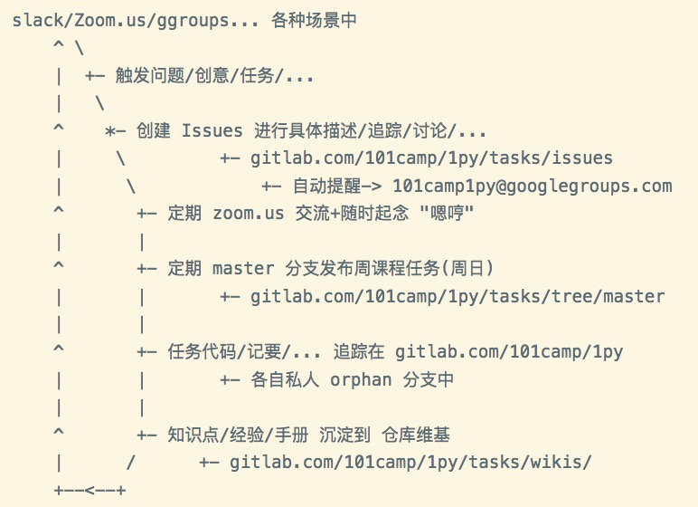

## PKM

> 个人知识管理

另一个课程

# learnning

[figure not shown]

## 亚里士多德

> “我们通过做来学习我们必须学习去做的…”

```
"For the things we have to learn
    before we can do them,
we learn by doing them."
~ Aristotle
```

## 知行合一

> 无分表里

[figure not shown]

知行合一的路径

## 咩算”学会”?

> 自检指标…

## 自信

> 当前经验,能->支撑完成目标任务

## MVP

> 降解到当前技能区间

[figure not shown]

如何构建 MVP

## 清点

> 蟒营嗯哼了什么?

## Python

> 生态

## 编程

> 过程

## 作品

> 节奏

## 问题

> 分解

## 沟通

> 姿势

## 工程

> 环境

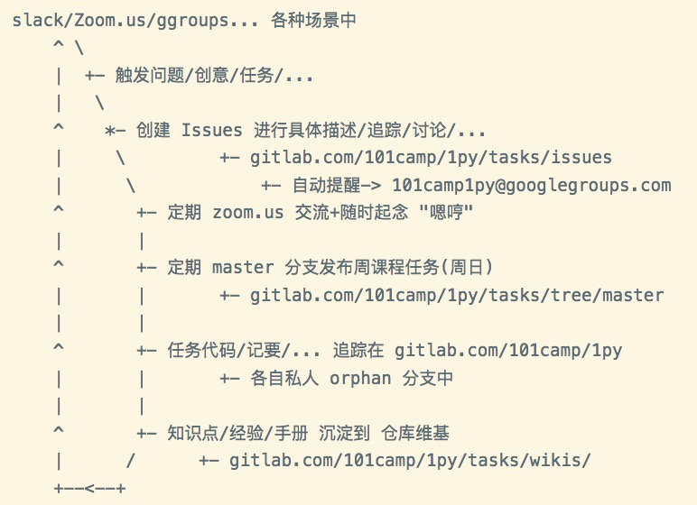

## 感谢

> 学员

## 周刊

> st

## 设计

> 若短衫

## 课程

> 迭代++

## 故事

> Issue

## 助教

> 蟒营核心动力

## PoL

> Proof of Learnning

自学通证

[figure not shown]

PoL

# (￣▽￣)

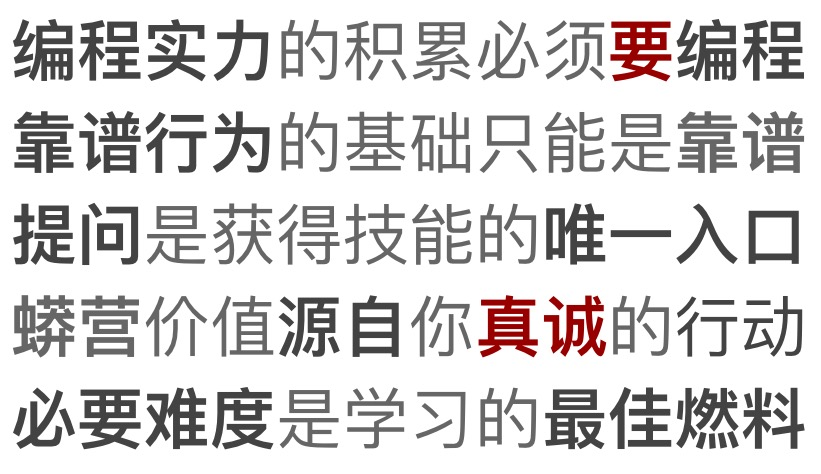

嗯哼

## 1py

> 101camp1py@googlegroups.com

保留

## 蟒营

> guru101camp@googlegroups.com

保留

## Slack

> 101camp.Slack.com

保留

## Group

> https://gitlab.com/101camp/1py

归档

## 复克

> 420元/人

## 通过

> 全额惠退

## 190701

> 101camp2py

## 自怼圈

> du.101.camp

190801

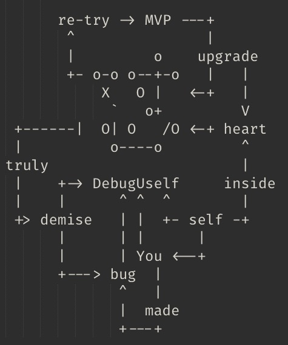

怼

## 幻灯

> NOT PPT

[slides.101.camp/101camp1pych10](http://slides.101.camp/101camp1pych10.html)

## 是也乎

- 190623 pub
- 190622 ++PoL
- 190621 init.

[figure not shown]

askdama@googlegroups.com

[figure not shown]

devops

# 嗯哼

## 真时帐

> 可PK -> 汇总 -> 回复 #115
- 客观数值
- 公平对比
- 基础数据

[figure not shown]

隐藏大坑

[figure not shown]

askdama@googlegroups.com

## 教练

> 蟒营导游

## 最困难?

- 不懂
- 不理解
- 不敢
- 不…

## 最帮助?

> 点穴

重新发现自己

## Levels

> 知识层级

## Unknow Unknow

> 不知己不知

## Unknow Know

> 不知己知何

## Know Knowed

> 知己何已知

## Know Unknow

> 知己何不知

[什么是”课”?](http://wiki.zoomquiet.io/IMHO/om-what-is-ke)

## GoogleGroups

- [电邮靠谱指南](http://blog.zhgdg.org/2014-02/email-kaopulity-guider/)
- [Gmail 生活指南](http://blog.zhgdg.org/2014-02/livin-gmail-guider/)
- [程序员必知必会之Email篇](http://blog.csdn.net/lanphaday/article/details/850059)
- [程序员必知必会之maillist篇](http://blog.csdn.net/lanphaday/article/details/1669326)

## Slack

- ? 微信
- ? QQ
- [为什么不应该使用QQ进行技术交流](http://blog.zhgdg.org/2013-06/anti-qq-as-tech-communication/)

[figure not shown]

任务泳道

## d0

> 每周从星期日开始

修整/新任务

## d1

> 破解

分析/理解/定义

## d2

> 探索

搜索/查阅/规划

## d3

> 检验

探索/实验/决策

## d4

> 实现

开发/测试/迭代

## d5

> 作品

迭代/优化/文档

## d6

> 生活

窜门/炫耀/休息

## 周一

> 2042 周刊发布
- 内部刊
- 活性/工量
- 责编 -> 全体
- 撰稿 -> 日常
  - 例会 Issue 回复

## 学习如何学

> self-teching

[自学是门手艺](https://mp.weixin.qq.com/s/S92_cpwMHfZH1JkpWJThXA)

## intro.

> uself
- 你是谁?
- 在哪儿?
- 为什么参加蟒营?

## 醉点

> 明明能,却不能

## 视而不见

> 在, 只是没注意

## [#58](https://gitlab.com/101camp/1py/tasks/issues/58#note_164892786)

> @hstaoqian101
- 什么值得 push
- git 探险经验

## 环境

> 用之, 弗学
- Issue -> 发问/起/记录/…
- Wiki -> 交付/沉淀/复用/..
- repo. -> 追踪/协同/原稿/…
- Slack -> 日常嗯哼/提醒
- ggroups -> 异步嗯哼/提醒/发布/通知
- 微信群 -> …

[figure not shown]

如何画马

## 意义

> [huyuning [May 3rd at 2:07 AM]](https://101camp.slack.com/archives/GH6U323NY/p1556820440119000)

项目逻辑赋予知识点意义

[figure not shown]

…

## 剪枝

> 聚焦注意力

## 人性?

> 人生本若逆旅

## IDD:0

> 生长 ~ IDD 正确打开姿势

## IDD:1

> 生长 ~ IDD 正确打开姿势

设想->实验

## IDD:2

> 生长 ~ IDD 正确打开姿势

实验->决策

## IDD:3

> 生长 ~ IDD 正确打开姿势

决策->追踪

## IDD:4

> 生长 ~ IDD 正确打开姿势

追踪->工作凭证

- commit
- duration

## IDD:5

> 生长 ~ IDD 正确打开姿势

凭证->规划

## PDCA

> 戴明环
- **P**lan 计划
- **D**o 执行
- **C**heck 检查
- **A**ct 处理

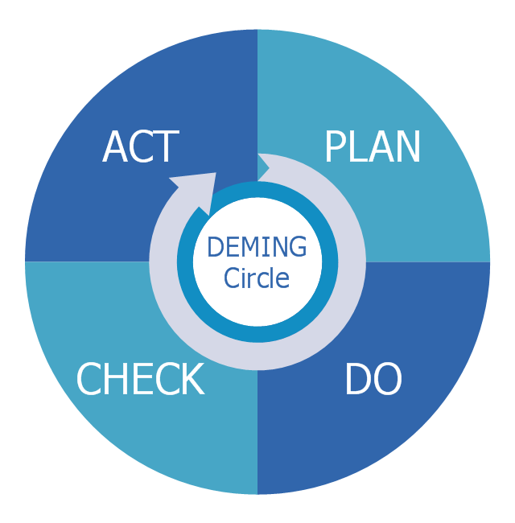

PDCA

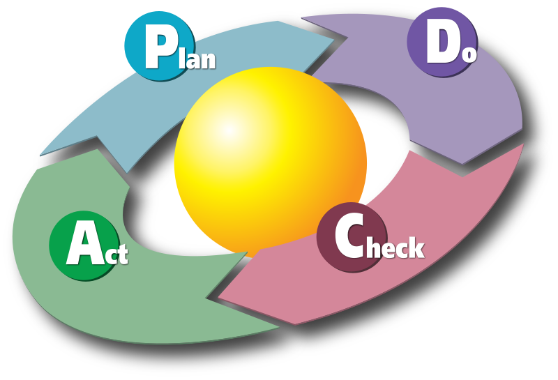

Cycle

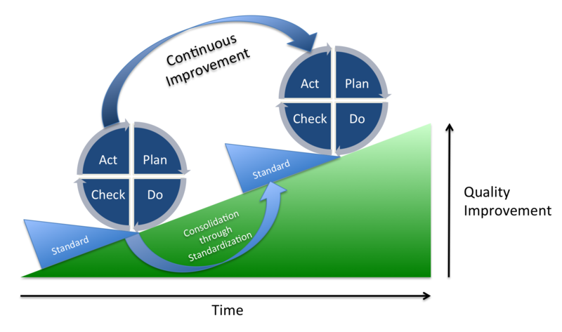

Process

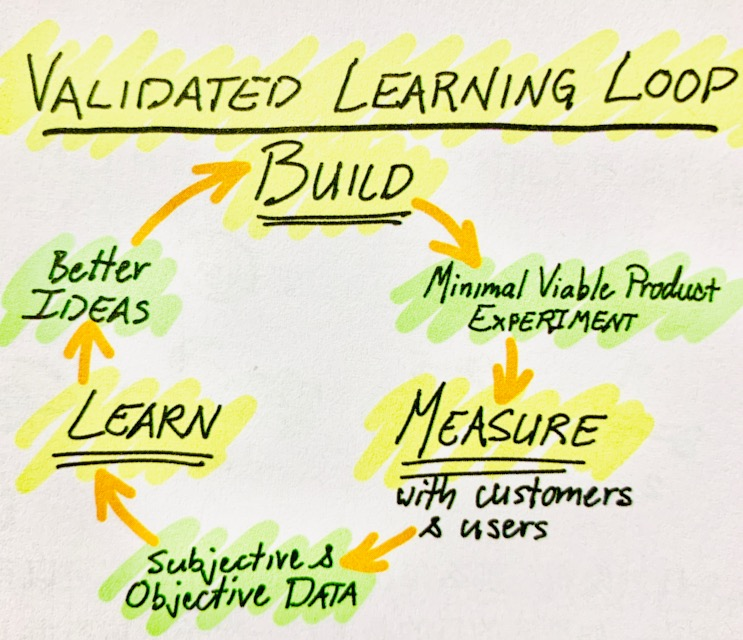

VLL

[figure not shown]

## 提问

> [+5 为什么?](https://www.jianshu.com/p/1afd14906c4a)

## 5W1H

> 思考框架…

## Who

> 版本/配置/…

## When

> 过程/输入/…

## Where

> 场景/上下文/…

## What

> 目标/问题/…

## Why

> 设想/分析/…

## How

> 实验/处置/..

## 3P.0

> “Sometimes you gotta RUN before you can WALK”

— Tony Stark

## 习惯

> 8周+

## 形成习惯

> 所谓8周+
- +2周熟悉
- +2周优化
- +2周检验
- +2周固化

## weekly

> 周日视为开始: d0

## 周日

> 2042 zoom.us
- WoW
- 单口/要点/…
- Q&A

## daily

> 嗯哼
- 固定时间
  - 10+小时/周
  - 42+分钟/天
- 探索解决
- 持续记录->交流

## 玻璃花园

> 串门儿
- Issue
- Commit-Comments
- Wiki

## AKA

> 环境 => All Know All

## 3P

> 3 Prophecy for Pain from Philosophy

> > 临兵斗者皆阵列在前

[破苦三谶言](https://youtu.be/HGaD661z3ng)

[figure not shown]

3P.0

## 3P.1

> Don’t fail it before “You fail it!”

只有不会失败, 才不会失败

## 3P.2

> 很多事儿,一动脑, 就完蛋了

远离颠倒梦想

[figure not shown]

知识螺旋

[figure not shown]

正确的画马流程

## IDD

> Issue Drive Devlop
- 计划
- 分解
- 追踪
- 证据

## IDD:0

> 生长 ~ IDD 正确打开姿势

规划->设想

## [#78](https://gitlab.com/101camp/1py/tasks/issues/78)

> @ljxzsx4

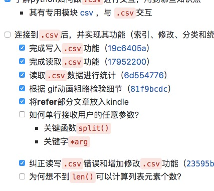

## d0

> 每周从星期日开始
- 解析/新任务
- 创建 Isue

## d1

> 破解
- 分析/理解/定义
- 细化问题

## d2

> 探索
- 搜索/查阅/规划
- 追踪记要探索过程

## d3

> 检验
- 探索/实验/决策
- 追踪代码实验版本

## d4

> 实现
- 开发/测试/迭代
- 规划并追踪功能点完成

## d5

> 作品
- 迭代/优化/文档
- 索引并发布有关嗯哼

## d6

> 生活
- 窜门/炫耀/休息
- 其它 Issue 讨论

## [#78](https://gitlab.com/101camp/1py/tasks/issues/78)

> @ljxzsx4

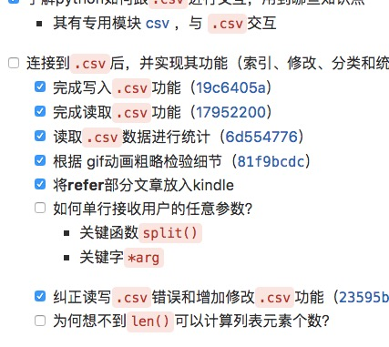

## 눈_눈

> 提醒

## [SSG](https://about.gitlab.com/2016/06/03/ssg-overview-gitlab-pages-part-1-dynamic-x-static/)

> Static Site Generators
- 101camp/1py/students
  - [1py/students/101camp.notes](https://101camp.gitlab.io/1py/students/101camp.notes/)

## [SMART 原则](https://wiki.mbalib.com/wiki/SMART%E5%8E%9F%E5%88%99)

> Peter Drucker [“管理的实践”](https://book.douban.com/subject/1832492/)
- **S**pecific 具体
- **M**easurable 可度量
- **A**ttainable 可达成
- **R**ealistic 可证明/观察
- **T**ime-based 有截止

## Kaopulity

> 靠谱
- **K**eep
- **a**ll
- **o**f
- **p**rocesses
- **u**sabi**lity**

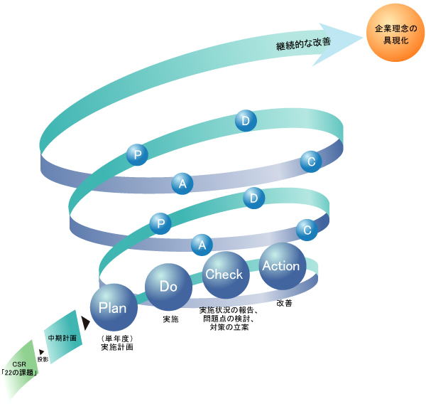

deming

[figure not shown]

Lean

- Together
- Explore
- All
- Mission

## naming

> 命名
- 中文全称
- 英文中名
- 缩写代号(全小写)
- 仓库/分支:…
- IDD: …

## goal

> 目标
- 具体场景
- 具体问题
- 具体解决
- 如何达成

## plan

> 计划
- 5W1H
- SMART

## trace

> 追踪
- scrum 协同
- 站立会议:
  - 完成了什么
  - 没完成什么
  - 计划完成什么
  - 需要什么帮助

## cooperate

> 协同
- 文档
- 开发
- 测试
- 演示(幻灯)
- …

## IDD:0

> 生长 ~ IDD 正确打开姿势

规划->设想

## d0

> 每周从星期日开始
- 解析/新任务
- 创建 Isue

## d1

> 破解
- 分析/理解/定义
- 细化问题

## d2

> 探索
- 搜索/查阅/规划
- 追踪记要探索过程

## d3

> 检验
- 探索/实验/决策
- 追踪代码实验版本

## d4

> 实现
- 开发/测试/迭代
- 规划并追踪功能点完成

## d5

> 作品
- 迭代/优化/文档
- 索引并发布有关嗯哼

## d6

> 生活
- 窜门/炫耀/休息
- 其它 Issue 讨论

## Levels

> 知识层级

## Unknow Unknow

> 不知己不知

## Unknow Know

> 不知己知何

## Know Knowed

> 知己何已知

## Know Unknow

> 知己何不知

## 蟒营?

> 体验总结

## 蟒营

> 总结体验, 安利未来

## => IDD

> Issue Drive Devlop
- 计划
- 分解
- 追踪
- 证据

## Pythonic

Fake it untill make it

## 能技

> 如何 访达 ?

```
能使
    目标对象
        对指定命题
        产生
    科学兴趣的
技术
```

## [Hacker](http://man.lupaworld.com/content/develop/joyfire/project/7.html#I660)

> NOT Cracker(骇客)

## Coding

> 编程

## Testing

> 测试

## Documant

> 文档

## Running

> 运营

## Spreading

> 传播,布道

Evangelist

## team

> 团队
- naming
- goal
- plan
- trace
- cooperate

## [#76](https://gitlab.com/101camp/1py/tasks/issues/76#note_168910180)

> @chengyuan101

`激发点` 设计连载

## SM:

> 隐藏任务 (Secret Mission)

## [提问的智慧](https://github.com/DebugUself/How-To-Ask-Questions-The-Smart-Way/blob/master/README-zh_CN.md)

> 认真嗯哼的技法…

## [#120](https://gitlab.com/101camp/1py/tasks/issues/120#note_181726076)

> unclejia

提问的智慧读后感

## 真团队

> 可PK
- <=3人
- 固定沟通
- 协同流程

## BP

> 路演大作业
- 只余1周
- 直播演示
- 开发计划
- 可用原型

## 诚意

> 如何证明自己是认真的?

## 认真作

> 投入->产出…

## 奢侈品

> 人工时间投入多

## 网络演示

- VLog
- Podcast
- blog
- PPT
- …

## 电梯演讲

> 1分钟,说明白一点